# Tweets Analysis

Douglas Paris

25/6/2021

# Análitica de texto `RTweet`

Twitter es una de las grandes redes sociales en todo el mundo, México incluido, con mas de 10 millones de usuarios activos mensuales, la información dentro de la red social de los 280 caracteres es una fuente de información inmensa. En este análsis se bsucaran dos palabres clave: *“hospitalizado(a)”* y *“COVID”*.

## Buscando tweets

Lo primero que obtendremos son los tweets que contengan las palabras COVID y hospitalizado (debido a la poca cantidad de tweets, se han agregado sinonimos como hospital o UCI). Posterior a esto eliminaremos palabras que no aportan niformación, como preposiciones asi como signos de puntuación y espacios adicionales. Observaremos si son tweets organicos, retweets o respuestas a tweets.

### Los tweets obtenidos con las palabras clave estan clasificados como sigue:

| category | count | percentage |
| --- | --- | --- |
| Organic | 17 | 60.714286 |
| Retweets | 9 | 32.142857 |
| Replies | 2 | 7.142857 |

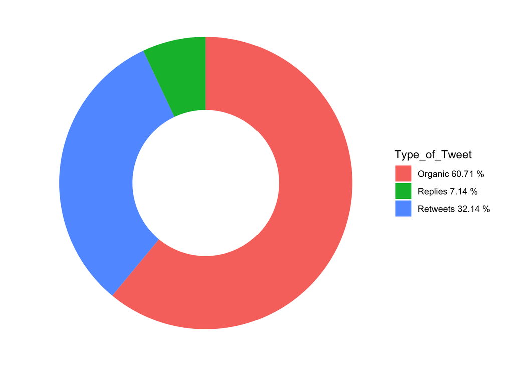

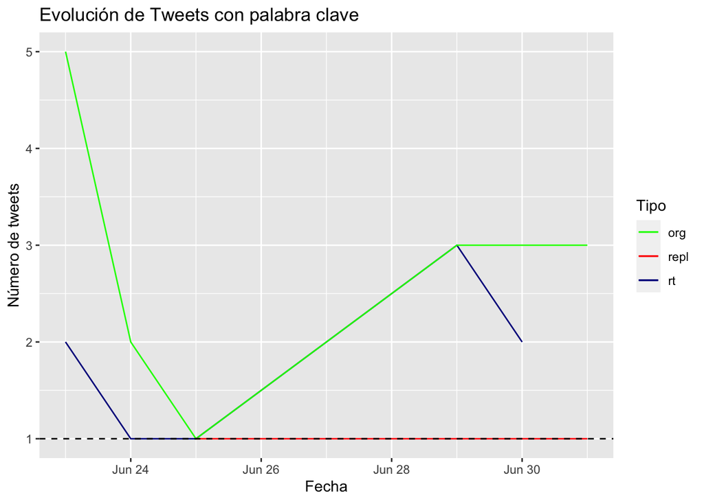

#### Nube Órganicos

A continuación, crearemos una nube de palabras con los tweets orgánicos, asi como la frecuencia de las top5 palabras, dandonos una idea principal de los tweets.

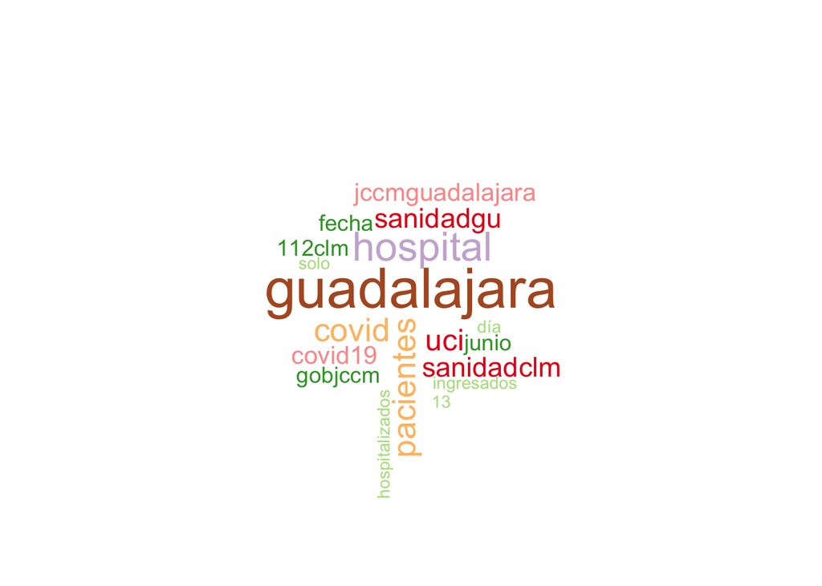

```r
top_wordscause <- topfeatures(dfm_nov_text, n = 5) %>%
  enframe(name = "palabra", value = "n")

top_wordscause
```

```
## # A tibble: 5 x 2
##   palabra         n
##   <chr>       <dbl>
## 1 guadalajara    19
## 2 hospital       13
## 3 pacientes      10
## 4 covid          10
## 5 uci             9
```

#### Análisis de Sentimientos

Gracias a la librería de “syuzhet”, nos permite profundizar aún más captando el tono de los tweets, asignando cada uno hacia un sentimiento relacionado con la percepción humana. Observamos que el mayor sentimiento es la confianza y la positividad, que se puede relacionar con la reciente confianza en el avance de las vacunas (no necesariamente esto es bueno, ya que a la gente puede bajar la guardia ante la pandemia).

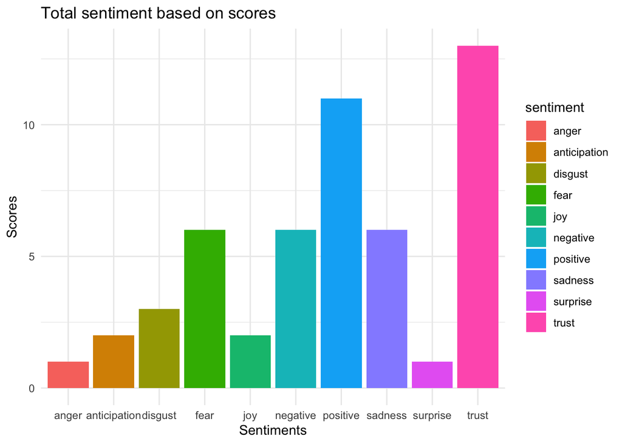